# Multilevel Modeling Diagnostics in R

January 26, 2019

In R, there are many quite a few diagnostic tools for MLM, although they are not necessarily straightforward to use. In this note I will show some basic tools.

## Importing Data Into R

We’ll import the data in .sav format.

```r
library(tidyverse)
theme_set(theme_bw())  # Use a different theme for plotting with ggplot2
library(lme4)
library(haven)
# Read in the data (pay attention to the directory)
hsball <- read_sav("../data/hsball.sav")
hsball <- as.data.frame(hsball)  # need this to get the influence statistics
```

## Fitting the model

We will use the example of a cross-level interaction model

```r
crlv_int <- lmer(mathach ~ meanses + sector * ses + (ses | id),
                 data = hsball)
```

# Diagnostic Plots

## Residuals (Lv 1.) vs. Every Predictor, Fitted Values

For: linearity, specification, outliers, homoscedasticity

You want to see a random blob with no clear patterns, such as a curvillinear shape

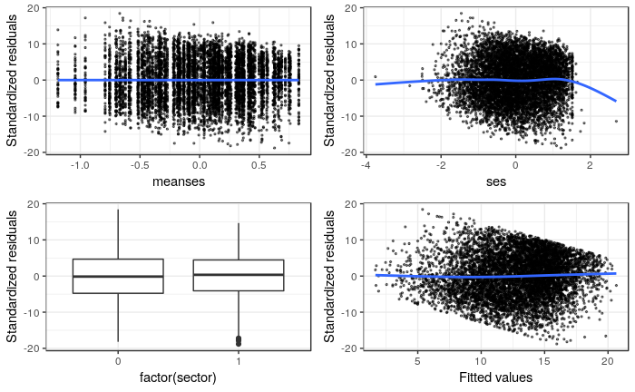

```r
# Augment the data with the fitted values and the standardized residuals
resid_df <- mutate(hsball,
                   .resid = resid(crlv_int),
                   .fitted = fitted(crlv_int))
# Residual vs. meanses
p1 <- ggplot(resid_df,
       aes(x = meanses, y = .resid)) +
  geom_point(size = 0.5, alpha = 0.5) +  # show the points
  geom_smooth(se = FALSE) +  # add a smoother
  labs(y = "Standardized residuals")
# Residual vs. ses
p2 <- ggplot(resid_df,
       aes(x = ses, y = .resid)) +
  geom_point(size = 0.5, alpha = 0.5) +  # show the points
  geom_smooth(se = FALSE) +  # add a smoother
  labs(y = "Standardized residuals")
# Residual vs. sector
p3 <- ggplot(resid_df,
       aes(x = factor(sector),  # factor() is used for categorical predictor
           y = .resid)) +
  geom_boxplot() +  # use boxplot with categorical predictor
  labs(y = "Standardized residuals")
# Residual vs. fitted
p4 <- ggplot(resid_df,
       aes(x = .fitted, y = .resid)) +
  geom_point(size = 0.5, alpha = 0.5) +  # show the points
  geom_smooth(se = FALSE) +  # add a smoother
  labs(y = "Standardized residuals", x = "Fitted values")
gridExtra::grid.arrange(p1, p2, p3, p4, nrow = 2L)
```

Linearity: The plots show no major violations of the linearity assumption, as the trend lines do not suggest unmodelled nonlinear relationships.

Specification: Correct specification is not easy to assess. It partly depends on whether any nonlinear relationships or interaction effects are omitted. From the plots, the residuals do not appear to be related to the predictors. *One thing to note, however, is that the residuals appear to be bounded, which can indicate a ceiling and/or a floor effect. This certainly is due to our outcome variable being bounded with a maximum of 25. A model that captures the boundedness (e.g., truncated normal) probably fit the data better.

Outliers: An outlier is one that lies outside the majority of the data. There was one student who had very low `ses` and one with very high `ses`. We should make sure those cases are reasonably values. Also we want to check whether there are cases with extremely high standardized residuals. In this example there are some cases with residuals $> 3$ or $< -3$, but they don’t look outrageously bad.